# Assignment

Terry Liu

## Question One

1. The world’s 10 largest companies yield the following data,(unit:billions)
1. Using `R` to plot the scatter diagram for the varaiblex $x_1$ and $x_2$. Comment on the appearance of the diagram

```r
data <- read.csv("Assignment1.csv", header = T)
head(data)
```

|  | Company | X1.sales | X2.profits | X3.assets |
| --- | --- | --- | --- | --- |
| 1 | Citigroup | 108.28 | 17.05 | 1484.10 |
| 2 | General Electric | 152.36 | 16.59 | 750.33 |
| 3 | American Inti Group | 95.04 | 10.91 | 766.42 |
| 4 | Bank of America | 65.45 | 14.14 | 1100.46 |
| 5 | HSBC Group | 62.97 | 9.52 | 1031.29 |
| 6 | ExxonMobil | 263.99 | 25.33 | 195.26 |

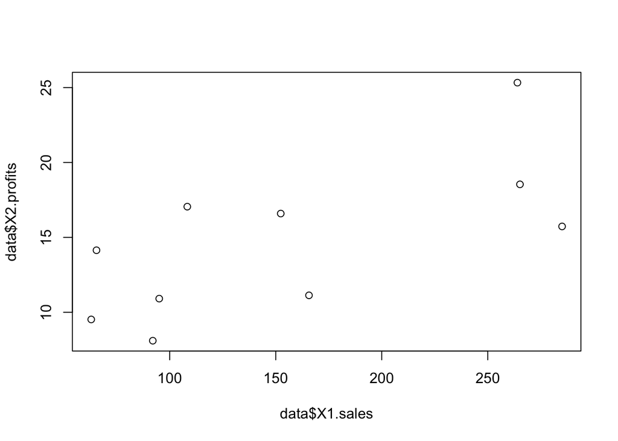

```r
plot(data$X1.sales, data$X2.profits)
```

2. Using R to plot the 3D scatter diagram of the world’s 10 largest comapnies data.

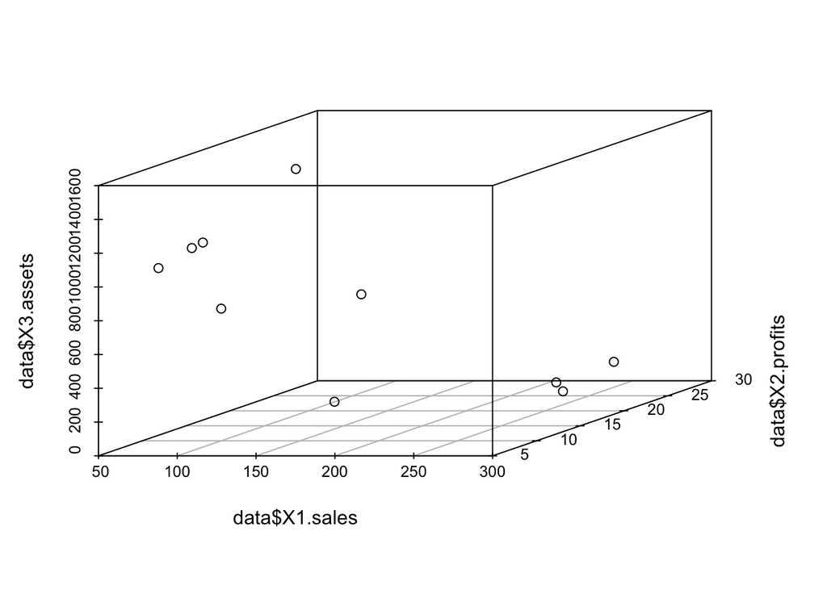

```r
library(scatterplot3d)
scatterplot3d(data$X1.sales, data$X2.profits, data$X3.assets)
```

3. Compute $\bar{x_1}, \bar{x_2}, S_{11}, S_{12}, S_{22}$ and $r_{12}$ and intepret $r_{12}$

```r
x_1 <- mean(data$X1.sales)
x_2 <- mean(data$X2.profits)
s_11 <- var(data$X1.sales)
s_12 <- var(data$X2.profits)
r_12 <- cor(data$X1.sales, data$X2.profits)
```

4. Represent the data in each of follwoing ways:(i) Stars; (ii) Chernoff faces; (iii) faces; Fourier scries plot (Andrews’ method)

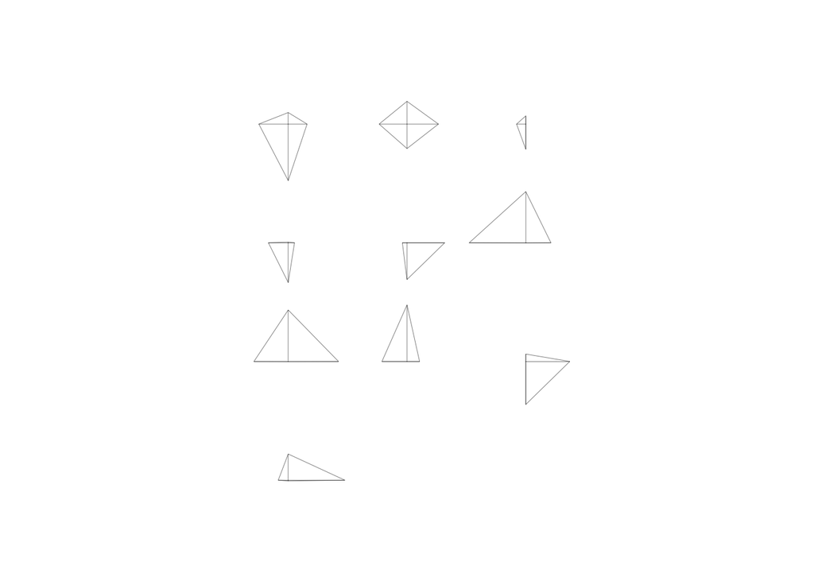

```r
# for Chernoff faces please install package: aplpack
# if you cannot install it properly
# please check the log;
# for mac, you need to install xquartz from:
# http://xquartz.macosforge.org

# stars plot
stars(data);
```